# Green Index Calculations by Subregion: Karlova District, Tartu, Estonia

Jessica Middleton

March 2026

# Introduction

This script calculates Green Index values for the historic residential core of Karlova, Tartu, Estonia, loosely following the methodology described in:

> *Urban Neighborhood Green Index – A measure of green spaces in urban areas* doi: 10.1016/j.landurbplan.2012.01.003

**Green Index Definition:** The percentage of greenery within each 100m × 100m grid cell, derived from binary classification of NDVI measurements. Cells are classified into four quality levels on a scale of 1 (trace amounts of greenness) - 4 (high greenness):

| Green Index Value | % Greenness in Cell | Label |
| --- | --- | --- |
| 1 | < 25% | Trace Amounts of Greenness |
| 2 | 25% – 49% | Low Greenness |
| 3 | 50% – 74% | Medium Greenness |
| 4 | ≥ 75% | High Greenness |

> *Note: The four equal interval classification was adopted for simplicity, as this index provides relative values for comparative evaluation between neighbourhoods rather than absolute values.*

# Workflow Summary

**Software:** RStudio (v2025.09.0-387), R (v4.5.1), QGIS (v3.28)  
**Validation:** Results verified post-analysis in QGIS (v3.28)

**Data sources:**

- NDVI data (TIFF, 10m × 10m resolution): provided by course instructors via Moodle
- Study area polygon (GeoPackage): generated by project groupmate

**Workflow steps:**

1. Load and reproject NDVI raster and study area polygon to EPSG:3857
2. Clip NDVI to study area extent
3. Create 100m × 100m aggregation grid
4. Binary-classify NDVI (containing greenness = NDVI > 0.25) and extract mean greenness per cell
5. Assign greenness labels from percentage thresholds
6. Export final masked grid as GeoPackage
7. Statistical testing (Kruskal-Wallis + Dunn’s post-hoc) by subregion

**NOTE:** Subregion boundaries were manually delineated in QGIS based on land use polygons. These subregions were joined to each Green Index cell based on location, and the results were saved as a geopackage and imported back into RStudio to continue with statistical testing.

# Libraries

```r
library(terra)          # Reading, processing, and analyzing raster and vector spatial data
library(sf)             # Handling vector spatial data
library(exactextractr)  # Extracting raster values within polygons (e.g. NDVI per grid cell)
library(dplyr)          # Data wrangling and manipulation (filtering, grouping, summarizing)
library(ggplot2)        # Creating plots and visualizations (e.g. boxplots)
library(dunn.test)      # Post-hoc Dunn's test following Kruskal-Wallis significance testing
library(multcompView)   # Generating compact letter displays from pairwise comparison results
library(writexl)        # Exporting data frames to Excel (.xlsx) files
library(knitr)          # Table formatting in R Markdown output
library(kableExtra)     # Table formatting in R Markdown output
```

# Data Preparation

## Load and Format NDVI Raster

```r
# Fix occasional CRS resolution errors with terra library
Sys.setenv(PROJ_LIB = system.file("proj", package = "terra"))
Sys.setenv(PROJ_DATA = system.file("proj", package = "terra"))

# Load NDVI raster and assign CRS
ndvi <- rast("Tartu_NDVI_2024_ver2.tif")
crs(ndvi) <- "epsg:3857"

# Confirm CRS assigned correctly
crs(ndvi, describe = TRUE)
```

```
##                       name authority code                              area
## 1 WGS 84 / Pseudo-Mercator      EPSG 3857 World between 85.06°S and 85.06°N
##                           extent
## 1 -180.00, 180.00, -85.06, 85.06
```

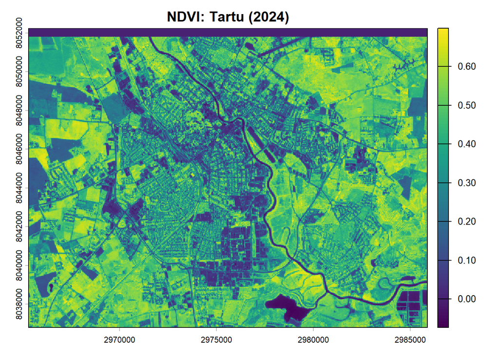

```r
# Visualize to confirm alignment with expected data
plot(ndvi, main = "NDVI: Tartu (2024)")
```

## Load and Format Study Area Polygon

```r
# Load study area polygon and reproject to match NDVI CRS
studyarea <- vect("research_area.gpkg")
studyarea <- project(studyarea, crs(ndvi))

# Confirm CRS alignment
crs(studyarea, describe = TRUE)
```

```
##                       name authority code                              area
## 1 WGS 84 / Pseudo-Mercator      EPSG 3857 World between 85.06°S and 85.06°N
##                           extent
## 1 -180.00, 180.00, -85.06, 85.06
```

```r
print(same.crs(ndvi, studyarea))
```

```
## [1] TRUE
```

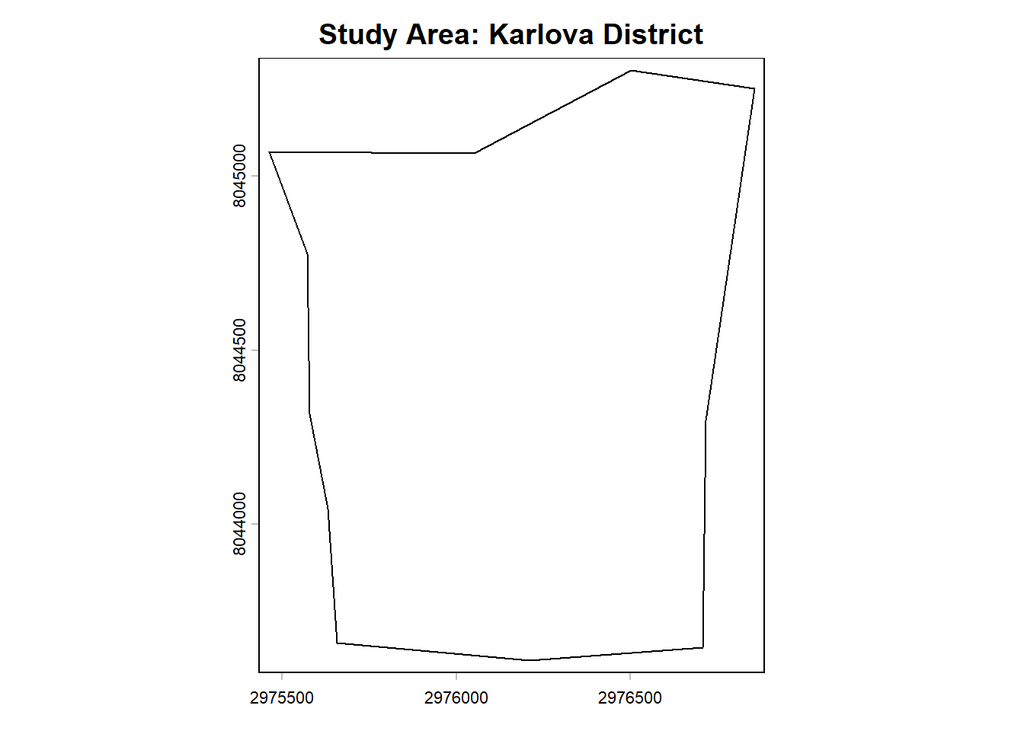

```r
# Visualize study area boundary
plot(studyarea, main = "Study Area: Karlova District")
```

## Confirm Initial Alignment

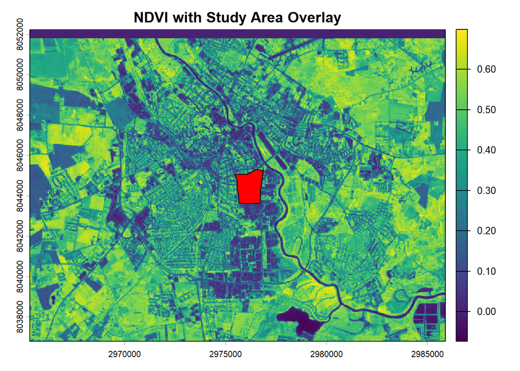

```r
# Overlay NDVI and study area to confirm spatial alignment before clipping
plot(ndvi, main = "NDVI with Study Area Overlay")
plot(studyarea, add = TRUE, col = "red")
```

## Clip NDVI to Study Area

```r
# Mask NDVI to study area extent
ndvi_masked <- mask(ndvi, studyarea)
ndvi_masked <- project(ndvi_masked, crs(ndvi))

# Confirm CRS consistency across all layers
crs(ndvi_masked, describe = TRUE)
```

```
##                       name authority code                              area
## 1 WGS 84 / Pseudo-Mercator      EPSG 3857 World between 85.06°S and 85.06°N
##                           extent
## 1 -180.00, 180.00, -85.06, 85.06
```

```r
print(same.crs(ndvi, studyarea) & same.crs(ndvi, ndvi_masked))
```

```
## [1] TRUE
```

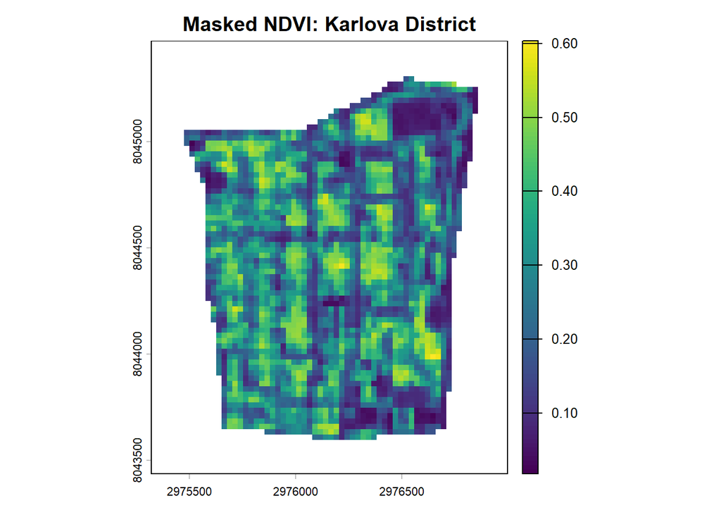

```r
# Plot masked NDVI with slight margin
bbox         <- st_bbox(studyarea)
x_range      <- bbox["xmax"] - bbox["xmin"]
y_range      <- bbox["ymax"] - bbox["ymin"]
margin_factor <- 0.1

expanded_bbox <- bbox
expanded_bbox["xmin"] <- bbox["xmin"] - margin_factor * x_range
expanded_bbox["xmax"] <- bbox["xmax"] + margin_factor * x_range
expanded_bbox["ymin"] <- bbox["ymin"] - margin_factor * y_range
expanded_bbox["ymax"] <- bbox["ymax"] + margin_factor * y_range

plot(ndvi_masked,
     main = "Masked NDVI: Karlova District",
     xlim = c(expanded_bbox["xmin"], expanded_bbox["xmax"]),
     ylim = c(expanded_bbox["ymin"], expanded_bbox["ymax"]))
```

# Calculate Green Index

**Green Index** = Percentage of greenness within each 100m × 100m grid cell

| % Green | Label |
| --- | --- |
| < 25% | Trace Amounts of Greenness |
| 25% – 49% | Low Greenness |
| 50% – 74% | Medium Greenness |
| ≥ 75% | High Greenness |

## Create 100m × 100m Aggregation Grid

```r
# Report original raster dimensions and resolution
cat("Original raster size:", ncol(ndvi_masked), "columns x", nrow(ndvi_masked), "rows\n")
cat("Original resolution: ", xres(ndvi_masked), "x", yres(ndvi_masked), "map units per pixel\n\n")

# Aggregate to 100m x 100m (10x the original 10m resolution)
new_cell_size_x <- xres(ndvi_masked) * 10
new_cell_size_y <- yres(ndvi_masked) * 10

grid    <- st_make_grid(st_as_sfc(st_bbox(ndvi_masked)),
                        cellsize = c(new_cell_size_x, new_cell_size_y),
                        square = TRUE)
grid_sf <- st_sf(id = seq_along(grid), geometry = grid)

cat("New grid size:", nrow(grid_sf), "cells\n")
cat("New cell size:", new_cell_size_x, "x", new_cell_size_y, "map units\n\n")

# Confirm CRS consistency
print(crs(grid_sf) == crs(ndvi_masked))
```

```
## Original raster size: 2055 columns x 1544 rows
## Original resolution:  10 x 10 map units per pixel
##
## New grid size: 31930 cells
## New cell size: 100 x 100 map units
##
## [1] TRUE
```

## Extract NDVI Values to Grid

> **Note:** Pixels outside the study area polygon were assigned `NaN` during masking. Cells with no valid NDVI data are excluded from analysis. Accuracy of the masked dataset was confirmed in QGIS during post-processing

```r
# Binary classification: pixels with NDVI > 0.25 are classified as green
green_pixels <- ndvi_masked > 0.25

# Extract mean greenness per grid cell and convert to percentage
green_percentage       <- exact_extract(green_pixels, grid_sf, 'mean') * 100
```

[output not shown]

```r
grid_sf$percent_green  <- round(green_percentage, 2)

# Remove cells with no valid data
valid_grid <- grid_sf[!is.na(grid_sf$percent_green), ]

print(head(valid_grid))
```

```
## Simple feature collection with 6 features and 2 fields
## Geometry type: POLYGON
## Dimension:     XY
## Bounding box:  xmin: 2975620 ymin: 8043600 xmax: 2976220 ymax: 8043700
## Projected CRS: WGS 84 / Pseudo-Mercator
##          id                       geometry percent_green
## 14112 14112 POLYGON ((2975620 8043600, ...         82.86
## 14113 14113 POLYGON ((2975720 8043600, ...         74.58
## 14114 14114 POLYGON ((2975820 8043600, ...         54.41
## 14115 14115 POLYGON ((2975920 8043600, ...         75.00
## 14116 14116 POLYGON ((2976020 8043600, ...         47.06
## 14117 14117 POLYGON ((2976120 8043600, ...         71.28
```

## Assign Greenness Labels

```r
# Classify grid cells into greenness categories based on percentage thresholds
grid_sf$greenness <- cut(
  grid_sf$percent_green,
  breaks = c(0, 25, 50, 75, 100),
  labels = c("Trace Amounts of Greenness",
             "Low Greenness",
             "Medium Greenness",
             "High Greenness"),
  include.lowest = TRUE,
  right = FALSE   # intervals are [0,25), [25,50), [50,75), [75,100]
)
```

## Plot Final Green Index and Verify Accuracy

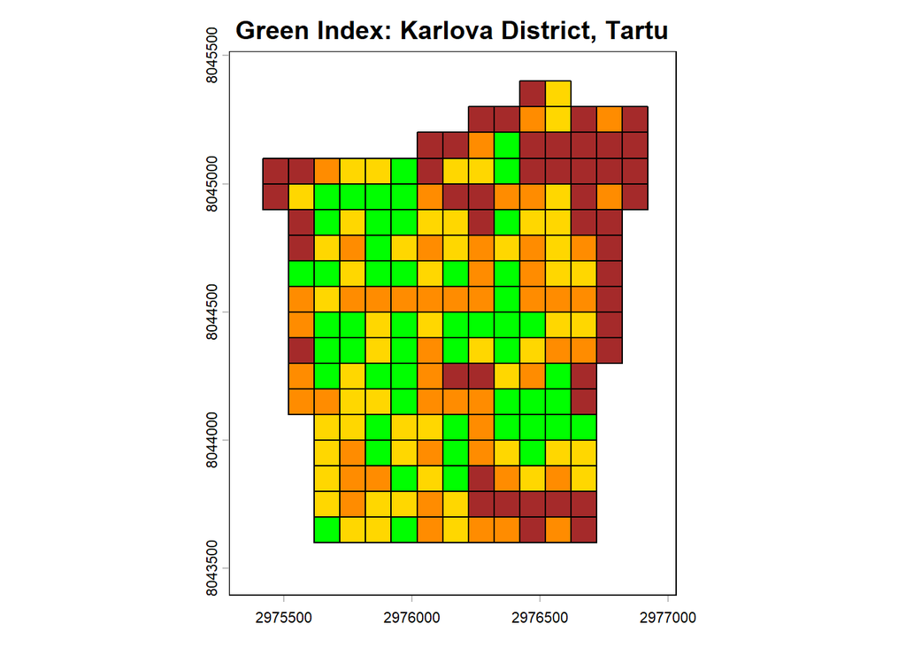

```r
# Define color scheme for greenness labels
colors <- c(
  "Trace Amounts of Greenness" = "brown",
  "Low Greenness" = "darkorange",
  "Medium Greenness" = "gold",
  "High Greenness" = "green"
)

# Compute expanded bounding box for plot context
bbox          <- st_bbox(studyarea)
x_range       <- bbox["xmax"] - bbox["xmin"]
y_range       <- bbox["ymax"] - bbox["ymin"]
margin_factor <- 0.1

expanded_bbox          <- bbox
expanded_bbox["xmin"]  <- bbox["xmin"] - margin_factor * x_range
expanded_bbox["xmax"]  <- bbox["xmax"] + margin_factor * x_range
expanded_bbox["ymin"]  <- bbox["ymin"] - margin_factor * y_range
expanded_bbox["ymax"]  <- bbox["ymax"] + margin_factor * y_range

# Remove NA cells, convert to SpatVector, and mask to study area
non_na_grid_sf   <- grid_sf[!is.na(grid_sf$greenness), ]
non_na_grid_vect <- vect(non_na_grid_sf)
masked_grid_sf   <- mask(non_na_grid_vect, studyarea)

# Plot with greenness color scheme
plot(masked_grid_sf["greenness"],
     col      = colors[as.character(masked_grid_sf$greenness)],
     main     = "Green Index: Karlova District, Tartu",
     cex.main = 1.2,
     xlim = c(expanded_bbox["xmin"], expanded_bbox["xmax"]),
     ylim = c(expanded_bbox["ymin"], expanded_bbox["ymax"]))
```